# Tercera Evaluación

- Mostrar todo el código
- Ocultar todo el código
- Ver el código fuente

Modelos estadísticos lineales

Ejercicios que muestran el uso de estas herramientas para analizar las relaciones entre variables y entender cómo las diferencias entre grupos pueden ser atribuidas a diferentes causas

Autores/as

Afiliación

Garcia Rios Santiago

[Facultad de Ciencias](https://www.fciencias.unam.mx/)

Víctor Jesús Martínez Contreras

Alejandra Castillo García

Fecha de publicación

28 de abril de 2024

**Ver librerías y datos**

```r
# librerias -------
library(tidyverse)
library(performance)
library(flextable)
library(sjPlot)
library(report)
library(ggstatsplot)
library(ggpubr)

# datos ------

tilapias <- read.csv("tilapias.csv")

toluca <- read.csv("toluca_tarea.csv")

aves <- read.csv("AbundanciaAves.csv")
```

## 1 Tilapias

> En un ejido en Veracruz un grupo de familias ha montado un sistema de crianza de tilapias y desean *conocer el efecto de la densidad de peces en el encierro y de la estación del año en el crecimiento* de los individuos. Para probar el efecto de estos factores, realizan un experimento en encierros en donde colocan 10, 18 o 24 individuos (niveles dentro del factor densidad). Pesan 9 peces antes y después del experimento (marcándolos para recapturar al mismo pez) y registran el incremento en peso al cabo de dos semanas. Realizan estas mediciones en verano y en primavera (factor estación del año). ¿Cuál es el efecto de la época del año y de la densidad de peces en el encierro en el crecimiento de las tilapias? Utiliza todos los recursos vistos en clase para presentar los resultados de este ejercicio. NOTA: Las mediciones en cada estación vienen de peces distintos.
1. Primero, cambiamos a factores los datos y exploramos nuestro dataframe:

**Ver código**

```r
# str(tilapias)
tilapias$densidad <- as.factor(tilapias$densidad)
tilapias$estacion <- as.factor(tilapias$estacion)


sjPlot::view_df(tilapias, show.frq = T, show.prc = T, show.na = T)
```

Data frame: tilapias

| ID | Name | Label | missings | Values | Value Labels | Freq. | % |
| --- | --- | --- | --- | --- | --- | --- | --- |
| 1 | densidad |  | 0 (0.00%) |  | 10 18 24 | 18 18 18 | 33.33 33.33 33.33 |
| 2 | estacion |  | 0 (0.00%) |  | primavera verano | 27 27 | 50.00 50.00 |
| 3 | aumento |  | 0 (0.00%) | *range: 60.0-402.0* |  |  |  |

2. Ahora, para determinar si hay un efecto significativo de nuestros dos factores (densidad y estación) en el crecimiento de las tilapias, podemos utilizar un ANOVA de dos vías:

**Ver código**

```r
aov_peces_1 <- aov(aumento ~  densidad * estacion, data = tilapias)

# summary(aov_peces_1)

# poner summary en formato markdown
sjPlot::tab_model(aov_peces_1,
                  # show.reflvl = T, # nivel de referencia para factores
                  # show.intercept = F,
                  p.style = "numeric_stars",
                  title = "aumento~densidad*estación"
                  )
# report::report(aov_peces_1) # resumen de nuestro modelo
```

Tabla 1: ANOVA de dos vías

aumento~densidad*estación

|  | aumento |
| --- | --- |
| Predictors | p |
| densidad | **<0.001** |
| estacion | **<0.001** |
| densidad:estacion | **<0.001** |
| Residuals |  |
| Observations | 54 |
| R<sup>2</sup> / R<sup>2</sup> adjusted | 0.936 / 0.929 |
| * p<0.05 ** p<0.01 *** p<0.001 |  |

El ANOVA (`fórmula aumento ~ densidad * estación`) sugiere que:

- El efecto principal de la **densidad** es estadísticamente significativo y grande (F(2, 48) = 119.20, p < .001; Eta2 (partial) = 0.83, 95% CI [0.76, 1.00]).
- El efecto principal de **estación** es estadísticamente significativo y grande (F(1, 48) = 432.63, p < .001; Eta2 (partial) = 0.90, 95% CI [0.86, 1.00]).
- La interacción entre *densidad y estación* es estadísticamente significativa y grande (F(2, 48) = 16.20, p < .001; Eta2 (partial) = 0.40, 95% CI [0.22, 1.00]).

El siguiente gráfico se realizó para ejemplificar la diferencia de medias (comparaciones múltiples ajustada con corrección de *Holm*) :

**Ver código**

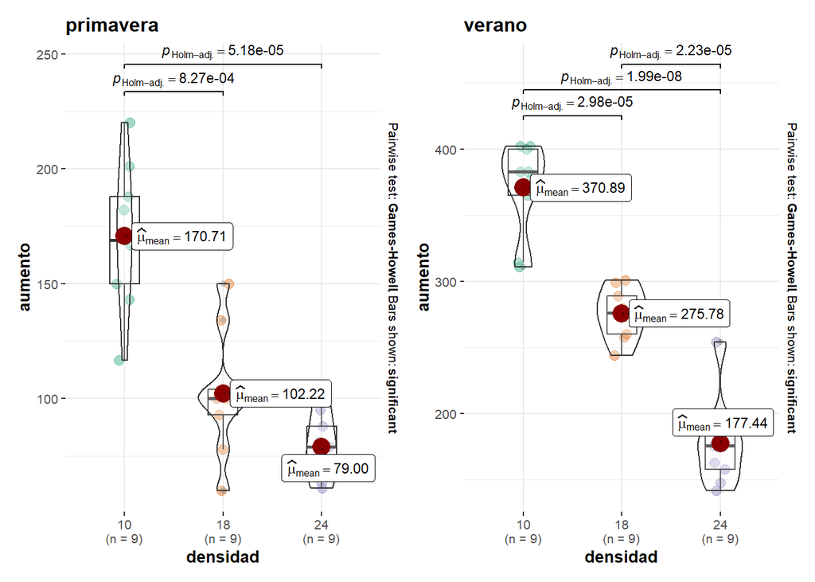

Figura 1: Diferencia de medias

```r
# es experimento de tipo between-subjects porque cada sujeto solo participa una vez en el experimento
ggstatsplot::grouped_ggbetweenstats(
  data = tilapias,
  x = densidad,
  y = aumento,
  grouping.var = estacion,
  type = "parametric",
  bf.message = F,
  results.subtitle = F
)
```

Supuestos del modelo:

**Ver código**

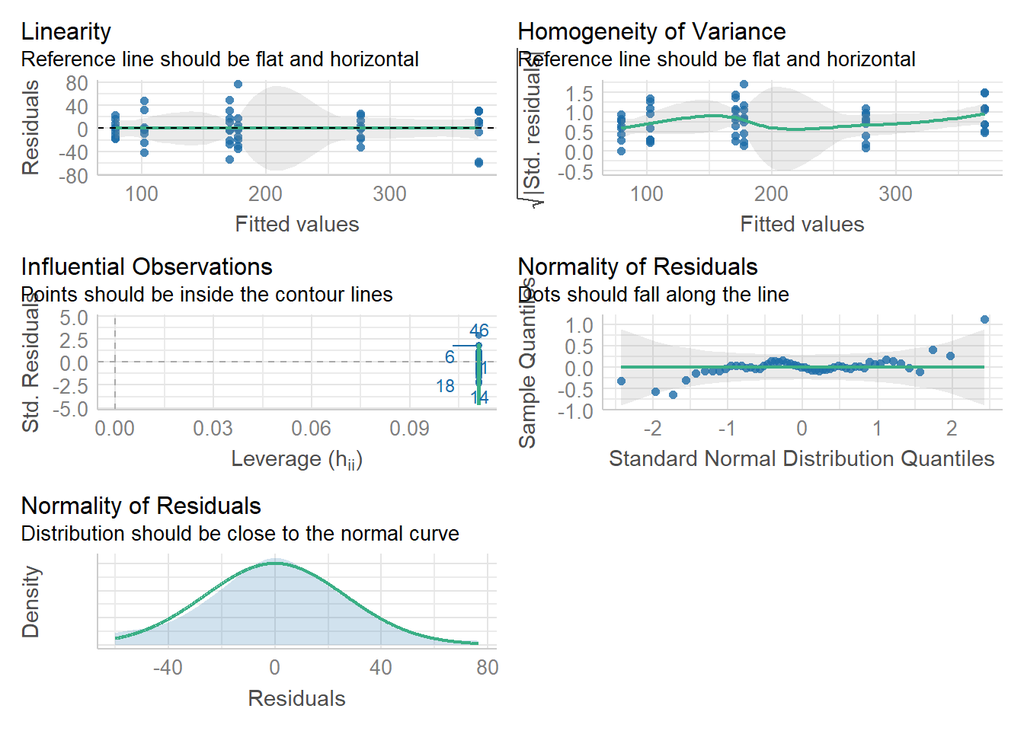

Figura 2: Supuestos del ANOVA

```r
# plot(aov_peces_1)
performance::check_model(aov_peces_1,
                         check = c("normality", "qq", "linearity", "homogeneity", "outliers")
                           )
```

Parce ser que no tenemos violaciones graves a nuestro modelo.

## 2 Tilapias por separado

> Analiza los mismos datos del ejercicio anterior pero probando el efecto de la estación y de la densidad por separado. ¿Qué diferencia encuentras en la interpretación de los resultados? Dado el diseño experimental y la pregunta central, ¿qué tipo de análisis es el más conveniente y por qué? No te olvides de revisar los supuestos.
1. **Densidad**:

**Ver código**

```r
# DENSIDAD
aov_peces_densidad <- aov(aumento ~ densidad, data = tilapias)
# summary(aov_peces_densidad)

sjPlot::tab_model(aov_peces_densidad,
                  # show.reflvl = T, # nivel de referencia para factores
                  # show.intercept = F,
                  p.style = "numeric_stars",
                  title = "aumento ~ densidad"
                  )
```

Tabla 2: ANOVA para densidad

aumento ~ densidad

|  | aumento |
| --- | --- |
| Predictors | p |
| densidad | **<0.001** |
| Residuals |  |
| Observations | 54 |
| R<sup>2</sup> / R<sup>2</sup> adjusted | 0.317 / 0.290 |
| * p<0.05 ** p<0.01 *** p<0.001 |  |

**Ver código**

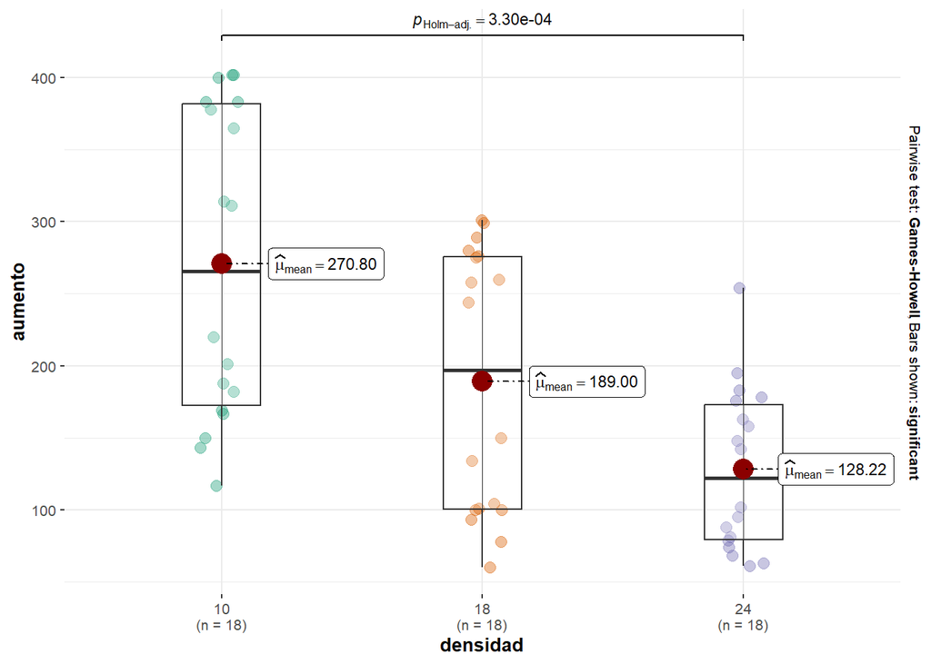

Figura 3: Diferencia de medias densidad

```r
# post hoc
ggstatsplot::ggbetweenstats(
  data = tilapias,
  x = densidad,
  y = aumento,
  type = "parametric",
  bf.message = F,
  results.subtitle = F,
  # remover violin plot
  violin.args = list(width = 0, linewidth = 0)
)

# report::report(aov_peces_densidad)
```

El ANOVA de densidad (`formula: aumento ~ densidad`) sugiere que el efecto principal de la densidad es estadísticamente significativo y grande (F(2, 51) = 11.85, p < .001; Eta2 = 0.32, 95% CI [0.14, 1.00]),.

**Ver código**

```r
# ESTACIÓN
aov_peces_estacion <- aov(aumento ~ estacion, data = tilapias)
# summary(aov_peces_estacion)

sjPlot::tab_model(aov_peces_estacion,
                  # show.reflvl = T, # nivel de referencia para factores
                  # show.intercept = F,
                  p.style = "numeric_stars",
                  title = "aumento~estacion"
                  )
```

Tabla 3: ANOVA para estación

aumento~estacion

|  | aumento |
| --- | --- |
| Predictors | p |
| estacion | **<0.001** |
| Residuals |  |
| Observations | 54 |
| R<sup>2</sup> / R<sup>2</sup> adjusted | 0.576 / 0.568 |
| * p<0.05 ** p<0.01 *** p<0.001 |  |

**Ver código**

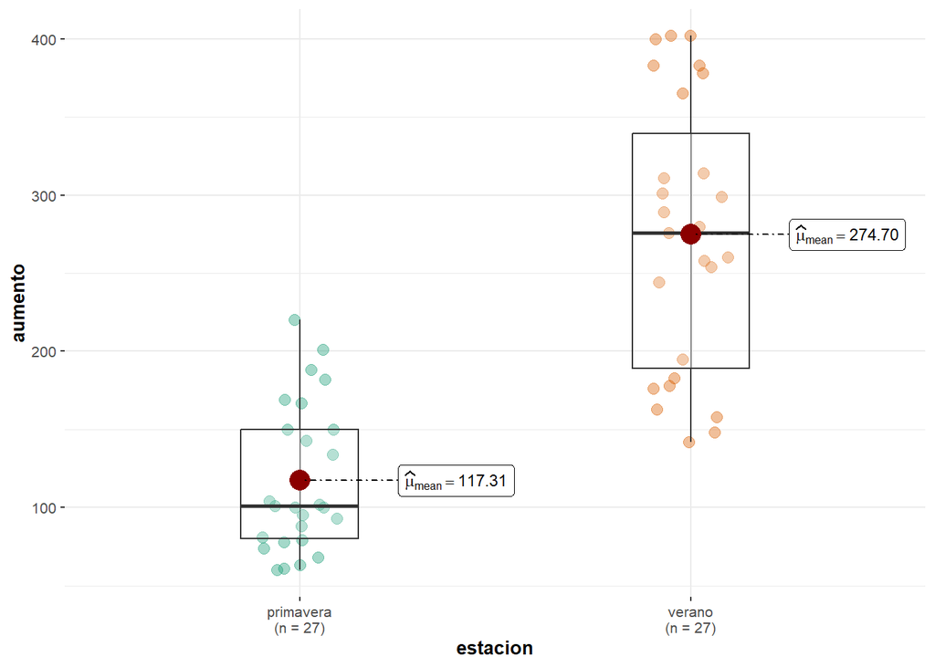

Figura 4: Diferencia de medias estación

```r
# post hoc
ggstatsplot::ggbetweenstats(
  data = tilapias,
  x = estacion,
  y = aumento,
  type = "parametric",
  bf.message = F,
  results.subtitle = F,
  # remover violin plot
  violin.args = list(width = 0, linewidth = 0)
)

# report::report(aov_peces_estacion)
```

El ANOVA de estación (formula: `aumento ~ estación`) sugiere que el efecto principal de la estación es estadísticamente significativo y grande (F(1, 52) = 70.57, p < .001; Eta2 = 0.58, 95% CI [0.43, 1.00]).

2. Revisar supuestos (parece que el modelo con interacción cumple mejor con los supuestos).

**Ver código**

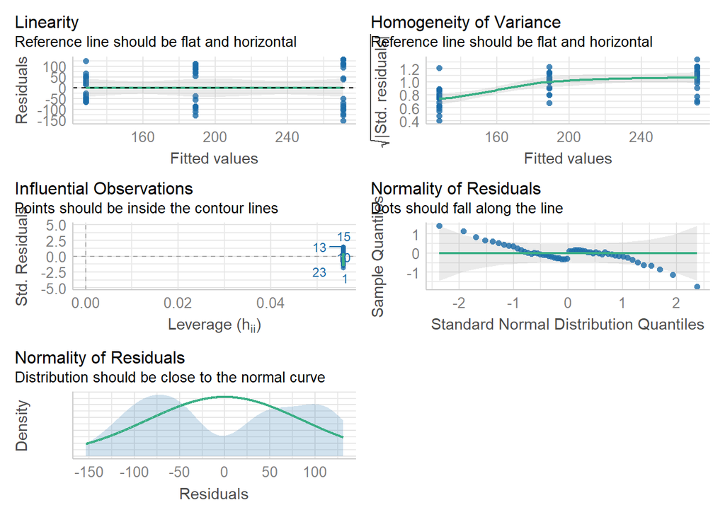

Figura 5: ANOVA densidad supuestos de modelo

```r
# DENSIDAD
performance::check_model(aov_peces_densidad, check = c("normality", "qq", "linearity", "homogeneity", "outliers"))
```

**Ver código**

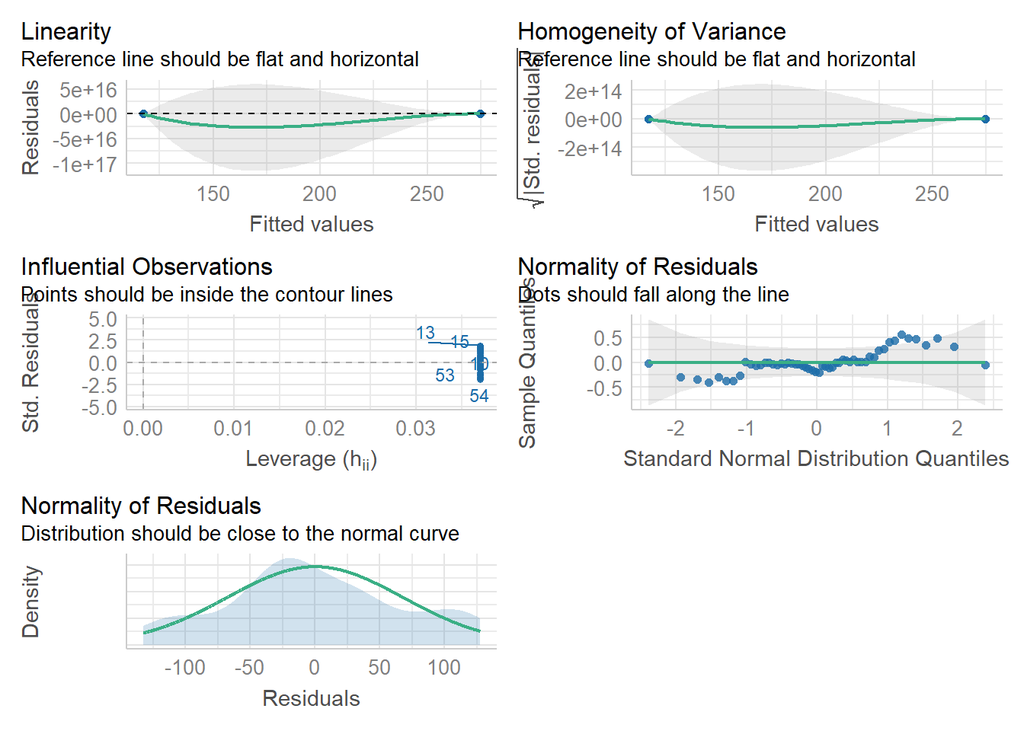

Figura 6: ANOVA estación supuestos de modelo

```r
# ESTACIÓN
performance::check_model(aov_peces_estacion, check = c("normality", "qq", "linearity", "homogeneity", "outliers"))
```

**Conclusión**

Si analizamos cada factor por separado, solo podemos concluir sobre el efecto individual de cada variable predictora, sin considerar una interacción entre estas variables. Es decir, no podríamos modelar correctamente si la densidad influye sobre el crecimiento de las tilapias dependiendo de la estación del año (o viceversa).

Nuestro diseño experimental sugiere que tanto la densidad como la estación podrían interaccionar en su efecto sobre el crecimiento de las tilapias. En este caso, el ANOVA de dos vías permite evaluar tanto los efectos principales de cada factor como su interacción. Este análisis permite comprender mejor el fenómeno y puede servir mejor en la practica (por ejemplo, para gestionar la crianza de tilapias en diferentes condiciones).

Debido a que los suspuestos del modelo con interacción fueron cumplidos de manera más satisfactoria a comparación de los modelos sin interacción podemos afirmar que el primer modelo es una mejor aproximación a lo que en realidad ocurre cuando los dos factores (densidad y estación) interactúan afectando el crecimiento de las tilapias. Por lo tanto, si se desea realizar una predicción sobre el crecimiento y la producción de tilapias aconsejamos utilizar el primer modelo con interacción por ser el más completo.

**Con Dummy variables**

NOTA, también se puede hacer el ejercicio como un modelo lineal con variables *dummy*:

```r
## en modelo lienal
factor(tilapias$densidad) # 3 niveles
```

```
 [1] 10 10 10 10 10 10 10 10 10 10 10 10 10 10 10 10 10 10 18 18 18 18 18 18 18
[26] 18 18 18 18 18 18 18 18 18 18 18 24 24 24 24 24 24 24 24 24 24 24 24 24 24
[51] 24 24 24 24
Levels: 10 18 24
```

```r
# numero de niveles
tilapias %>% dplyr::group_by(densidad) %>%
  summarise(n = n())
```

```
# A tibble: 3 × 2
  densidad     n
  <fct>    <int>
1 10          18
2 18          18
3 24          18
```

```r
# tenemos una n = 18
n_densidad <- 18

# Crear variables dummy
tilapias_dummy <- tilapias %>% mutate(
  # dummy_densidad_a, rep(c(1, 0, 0), each = n_densidad), # intercepto
  dummy_densidad_b = rep(c(0, 1, 0), each = n_densidad),
  dummy_densidad_c = rep(c(0, 0, 1), each = n_densidad),
)


lm_peces_dummy_densidad <- lm(aumento ~ 1 + dummy_densidad_b + dummy_densidad_c,
                              data = tilapias_dummy)



# Resultado es idéntico si lo hacemos con los datos "crudos"
lm_peces_densidad <- lm(aumento ~ densidad, data = tilapias)
```

```r
summary(lm_peces_dummy_densidad)
```

```
Call:
lm(formula = aumento ~ 1 + dummy_densidad_b + dummy_densidad_c,
    data = tilapias_dummy)

Residuals:
     Min       1Q   Median       3Q      Max
-154.100  -79.550   -6.222   82.250  131.200

Coefficients:
                 Estimate Std. Error t value Pr(>|t|)
(Intercept)        270.80      20.78  13.029  < 2e-16 ***
dummy_densidad_b   -81.80      29.39  -2.783  0.00754 **
dummy_densidad_c  -142.58      29.39  -4.851  1.2e-05 ***
---
Signif. codes:  0 '***' 0.001 '**' 0.01 '*' 0.05 '.' 0.1 ' ' 1

Residual standard error: 88.18 on 51 degrees of freedom
Multiple R-squared:  0.3173,    Adjusted R-squared:  0.2905
F-statistic: 11.85 on 2 and 51 DF,  p-value: 5.937e-05
```

```r
summary(lm_peces_densidad)
```

```
Call:
lm(formula = aumento ~ densidad, data = tilapias)

Residuals:
     Min       1Q   Median       3Q      Max
-154.100  -79.550   -6.222   82.250  131.200

Coefficients:
            Estimate Std. Error t value Pr(>|t|)
(Intercept)   270.80      20.78  13.029  < 2e-16 ***
densidad18    -81.80      29.39  -2.783  0.00754 **
densidad24   -142.58      29.39  -4.851  1.2e-05 ***
---
Signif. codes:  0 '***' 0.001 '**' 0.01 '*' 0.05 '.' 0.1 ' ' 1

Residual standard error: 88.18 on 51 degrees of freedom
Multiple R-squared:  0.3173,    Adjusted R-squared:  0.2905
F-statistic: 11.85 on 2 and 51 DF,  p-value: 5.937e-05
```

Como se observa, ambos enfoques dan el mismo resultado.

## 3 Producción Maíz 2009

> Estos datos provienen de un estudio del maíz en un área periurbana. Aunque hay más variables en la base, para este ejercicio queremos construir un modelo que permita predecir la producción de 2009 (variable produccion_2009) a partir de las hectáreas sembradas (ha_maiz). ¿Qué tan bueno es este modelo para realizar predicciones? Utiliza todos los recursos vistos en clase para contestar. NOTA. Elimina el dato con producción de 2009 igual a cero, pues el entrevistador ha reportado que se trata de un error de captura
1. Primero eliminamos datos con error (`produccion_2009 = 0`):

**Ver código**

```r
# eliminar 2009 == 0
toluca <- toluca[toluca$produccion_2009 != 0, ]
```

2. Ahora, realizamos el *modelado estadístico*:

**Ver código**

```r
# ver tipo de variables que tenemos
# str(toluca$produccion_2009) # int
# str(toluca$ha_maiz) # num

# vamos a ajustar un modelo lineal

lm_produccion_2009 <- lm(produccion_2009 ~ ha_maiz, data = toluca)
# summary(lm_produccion_2009)

# report::report(lm_produccion_2009)

sjPlot::tab_model(lm_produccion_2009,
                  # show.reflvl = T, # nivel de referencia para factores
                  # show.intercept = F,
                  p.style = "numeric_stars",
                  title = "produccion_2009 ~ ha_maiz"
                  )
```

Tabla 4: Producción de 2009 a partir de hectáreas de maíz

produccion_2009 ~ ha_maiz

|  | produccion 2009 |  |  |
| --- | --- | --- | --- |
| Predictors | Estimates | CI | p |
| (Intercept) | 3.41 | -1070.72 – 1077.53 | 0.995 |
| ha maiz | 1969.97 *** | 1592.37 – 2347.57 | **<0.001** |
| Observations | 82 |  |  |
| R<sup>2</sup> / R<sup>2</sup> adjusted | 0.574 / 0.569 |  |  |
| * p<0.05 ** p<0.01 *** p<0.001 |  |  |  |

Ajustamos un modelo lineal (estimado usando OLS) para predecir la producción (produccion_2009) a partir de las hectáreas de maíz (fórmula: produccion_2009 ~ ha_maiz). El modelo explica una proporción de varianza estadísticamente significativa y sustancial (R2 = 0.57, F(1, 80) = 107.79, p < .001, R2 ajustado = 0.57).

- El intercepto del modelo, correspondiente a ha_maiz = 0, está en 3.41 (IC del 95% [-1070.72, 1077.53], t(80) = 6.31e-03, p = 0.995).

Dentro de este modelo:

- El efecto de ha_maiz es estadísticamente significativo y positivo (beta = 1969.97, IC del 95% [1592.37, 2347.57], t(80) = 10.38, p < .001; beta estandarizada = 0.76, IC del 95% [0.61, 0.90])

Los parámetros estandarizados se obtuvieron ajustando el modelo en una versión estandarizada del conjunto de datos. Los intervalos de confianza del 95% (IC) y los *p-values* se calcularon utilizando una aproximación de la distribución t de Wald.

Ahora, revisamos los supuestos del modelo:

**Ver código**

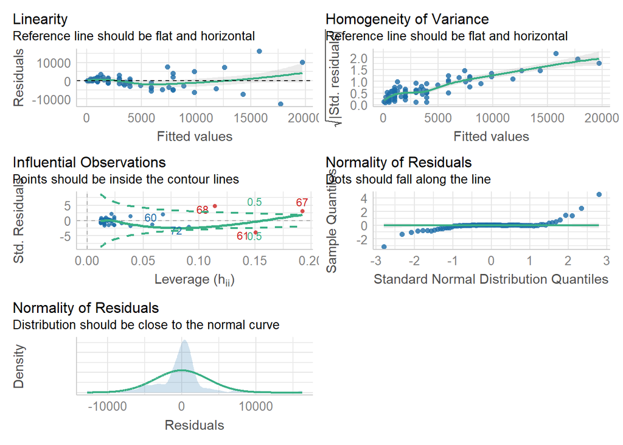

Figura 7: Supuestos del modelo lineal con un predictor

```r
performance::check_model(lm_produccion_2009,
                         check = c("normality", "qq", "linearity", "homogeneity", "outliers", "vif"))
 # parece que no cumple del todo con los supuestos
```

## 4 Maíz II

> Utilizando de nuevo los datos del estudio de maíz periurbano, realiza una comparación entre la producción del 2009 entre las diferentes comunidades. Sabemos que la producción está asociada con el área sembrada, por lo que quisiéramos tomar esto en cuenta en nuestro análisis al comparar las comunidades, i.e. queremos incorporar la covariable hectáreas sembradas de maíz (ha_maiz). ¿Hay diferencias en producción entre los sitios tomando en cuenta las hectáreas sembradas de maíz? Aunque no se detecte una diferencia significativa entre comunidades, ¿cuál sería la ecuación de regresión para cada comunidad (la finalidad es ejercitar el uso de las variables dummy)? Genera la gráfica correspondiente con tres rectas, una para cada comunidad a partir de las ecuaciones que generaste para cada comunidad.

R automáticamente toma una de las categorías como referencia, por lo que necesitamos generar manualmente las variables *dummy*.

**Ver código**

```r
# variable comunidad como un factor
toluca$comunidad <- as.factor(toluca$comunidad)
# str(toluca$comunidad) # verificar que sea un factor

# Modelo de regresión lineal
lm_produccion_2009_II<- lm(produccion_2009 ~ ha_maiz + comunidad, data = toluca)

# summary(lm_produccion_2009_II)

sjPlot::tab_model(lm_produccion_2009_II,
                  # show.reflvl = T, # nivel de referencia para factores
                  # show.intercept = F,
                  p.style = "numeric_stars",
                  title = "produccion_2009 ~ ha_maiz + comunidad"
                  )
```

Tabla 5: Modelo lineal con dos predictores

produccion_2009 ~ ha_maiz + comunidad

|  | produccion 2009 |  |  |
| --- | --- | --- | --- |
| Predictors | Estimates | CI | p |
| (Intercept) | 121.76 | -1568.54 – 1812.05 | 0.886 |
| ha maiz | 1936.41 *** | 1491.20 – 2381.63 | **<0.001** |
| comunidad [paredon] | 154.83 | -2252.40 – 2562.07 | 0.898 |
| comunidad [sanfrancisco] | -220.45 | -2212.24 – 1771.33 | 0.826 |
| Observations | 82 |  |  |
| R<sup>2</sup> / R<sup>2</sup> adjusted | 0.575 / 0.558 |  |  |
| * p<0.05 ** p<0.01 *** p<0.001 |  |  |  |

Sin embargo, también podemos hacer las variables *dummy* manualmente (a manera de un *ANCOVA*):

**Ver código para codificar variables dummy**

```r
## revisar cuántos niveles tienen nuestros factores
# factor(toluca$comunidad) # 3 niveles - chapultepec, paredon, sanfrancisco

# hacer nuevo dataframe
toluca_dummy <-  toluca |>
  dplyr::select(produccion_2009, ha_maiz, comunidad) |>
  drop_na()


# Crear variables dummy con mutate + case_when

toluca_dummy_casewhen <- toluca_dummy |>
  # este es el intercepto y no es necesario
  #
  # mutate(
  #   dummy_comunidad_a = case_when(
  #     comunidad == "chapultepec" ~ 1,
  #     .default = as.numeric(0)
  #   )
  # ) |>
  #
  mutate(
    dummy_comunidad_b = case_when(
      comunidad == "paredon" ~ 1,
      .default = as.numeric(0) # valor cuando no se cumple condición
    )
  ) |>
    mutate(
    dummy_comunidad_c = case_when(
      comunidad == "sanfrancisco" ~ 1,
      .default = as.numeric(0)
    )
  )

# Modelo de regresión con dummies para comunidad

lm_produccion_2009_II_dummy<- lm(produccion_2009 ~ ha_maiz +  dummy_comunidad_b + dummy_comunidad_c, data = toluca_dummy_casewhen)

# summary(lm_produccion_2009_II_dummy)

sjPlot::tab_model(lm_produccion_2009_II_dummy,
                  # show.reflvl = T, # nivel de referencia para factores
                  # show.intercept = F,
                  p.style = "numeric_stars",
                  title = "produccion_2009 ~ ha_maiz +  dummy_comunidad_b + dummy_comunidad_c"
                  )
```

Tabla 6: Modelo lineal con predictores dummy

produccion_2009 ~ ha_maiz + dummy_comunidad_b + dummy_comunidad_c

|  | produccion 2009 |  |  |
| --- | --- | --- | --- |
| Predictors | Estimates | CI | p |
| (Intercept) | 121.76 | -1568.54 – 1812.05 | 0.886 |
| ha maiz | 1936.41 *** | 1491.20 – 2381.63 | **<0.001** |
| dummy comunidad b | 154.83 | -2252.40 – 2562.07 | 0.898 |
| dummy comunidad c | -220.45 | -2212.24 – 1771.33 | 0.826 |
| Observations | 82 |  |  |
| R<sup>2</sup> / R<sup>2</sup> adjusted | 0.575 / 0.558 |  |  |
| * p<0.05 ** p<0.01 *** p<0.001 |  |  |  |

Los coeficientes de los modelos corresponden a las hectáreas sembradas y para las diferencias entre las comunidades (ajustadas por las hectáreas). Esto nos permite interpretar cómo difiere la producción entre comunidades, controlando por el tamaño del área sembrada.

Nuestro modelo sugiere que añadir la comunidad al modelo no explica los cambios en la producción de 2009.

- Las ecuaciones de regresión para nuestros modelos son:

**Ver código**

```r
# Ecuación de regresión
equatiomatic::extract_eq(lm_produccion_2009_II)
```

$$\operatorname{produccion\_2009} = \alpha + \beta_{1}(\operatorname{ha\_maiz}) + \beta_{2}(\operatorname{comunidad}_{\operatorname{paredon}}) + \beta_{3}(\operatorname{comunidad}_{\operatorname{sanfrancisco}}) + \epsilon$$

**Ver código**

```r
# Ecuación de regresión con dummys
equatiomatic::extract_eq(lm_produccion_2009_II_dummy)
```

$$\operatorname{produccion\_2009} = \alpha + \beta_{1}(\operatorname{ha\_maiz}) + \beta_{2}(\operatorname{dummy\_comunidad\_b}) + \beta_{3}(\operatorname{dummy\_comunidad\_c}) + \epsilon$$

Como se observa, ambos enfoques dan exactamente el mismo resultado.

- Visualización del modelo con las Rectas de Regresión para cada comunidad:

**Ver código**

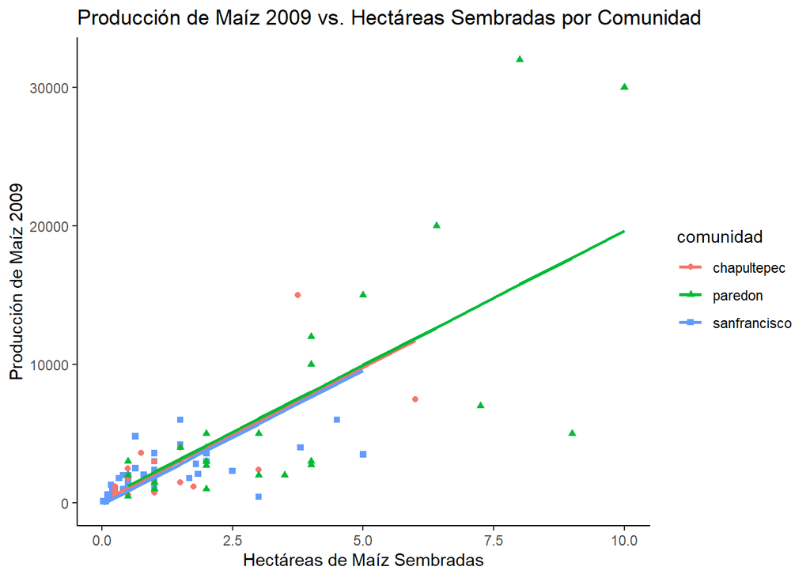

Figura 8: Regresión lineal del modelo con comunidades

```r
toluca_dummy$predicciones = predict(lm(produccion_2009 ~ ha_maiz + comunidad, data = toluca_dummy, interval = "confidence"))

# Plot
ggplot(toluca_dummy,
       aes(
         x = ha_maiz,
         y = produccion_2009,
         color = comunidad,
         shape = comunidad
       )) +
  geom_point() +
  geom_line(aes(y = predicciones), lwd = 1) +
  labs(title = "Producción de Maíz 2009 vs. Hectáreas Sembradas por Comunidad",
       x = "Hectáreas de Maíz Sembradas",
       y = "Producción de Maíz 2009") +
  theme_classic()
```

## 5 Aves de Australia

> Entender qué aspectos del ambiente y de las actividades humanas afectan la abundancia de organismos es un aspecto muy importante para la conservación de áreas naturales. En 1987 se colectaron datos de aves en 56 parches de vegetación natural en Australia. En este estudio se registró la abundancia de aves (abundancia) y algunas variables que serán utilizadas como predictoras de esta abundancia, incluyendo el área del parche medido (area), el tiempo en años en que dicho parche ha quedado aislado del resto de la vegetación natural (anos.aislam), la distancia al parche de vegetación más cercano (dist), la distancia al parche más grande de vegetación en el área (dist.parche.grande), la cantidad de ganado presente en el parche (ganado, medido de 1 a 5 donde 1 es poco ganado y 5 es abundante ganado), y la altitud. Se tienen en total seis variables predictoras. OJO: Revisa que exista una relación lineal entre la variable de respuesta y las predictoras. Es posible que algunas requieran una transformación.

### 5.1 Relación Lineal y transformaciones

1. Hacemos un gráfico con las 6 variables predictoras y añadimos una correlación de Pearson para evaluar la relación lineal.

**Ver código**

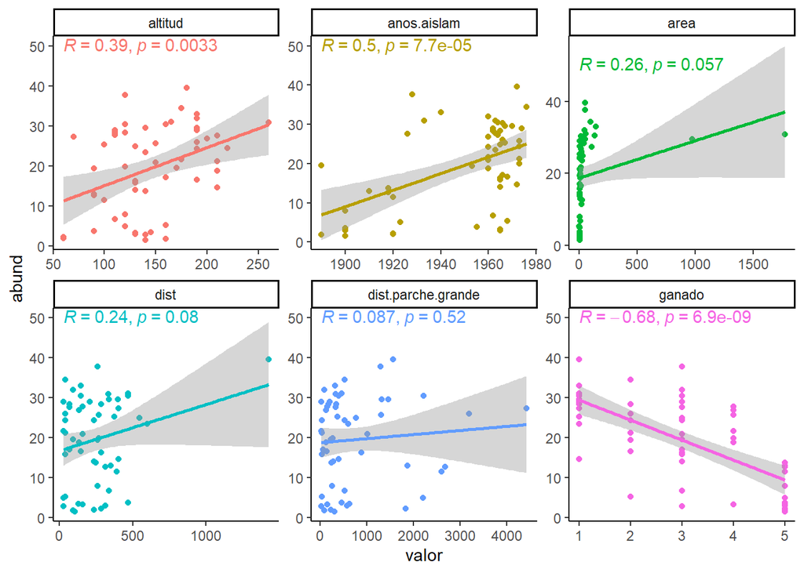

Figura 9: Relación lineal de variables predictoras

```r
# reunir variables para graficar en un solo paso
aves.gathered <- aves %>%
  gather(key = "variable", value = "valor",
         -abund) # remover variables de respuesta


# hacer el gráfico
ggplot(aves.gathered, aes(x = valor, y = abund, color = variable)) +
  geom_point() +
  geom_smooth(method = "lm") +
  facet_wrap(~variable, scales = "free") +
  theme_classic() +
  theme(legend.position = "none") +
  stat_cor(method = "pearson", label.y = 50) # librería ggpubr

# tal vez transformar y/o remover outliers
```

- altitud no se ve mal, pero tal vez podría mejorar con log?
- anos.aislam no se ve mal, pero tal vez podría mejorar con log?
- area, remover outliers o log?
- dist, remover outliers o log?
- dist.parche.grande tal vez podría mejorar con log?
- ganado parece bien

**Ver código**

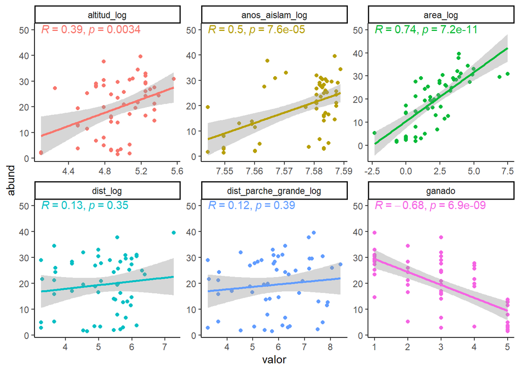

Figura 10: Relación lineal de variables predictoras log transformadas

```r
# Transformar Log
aves_log <- aves %>%
  mutate(
    altitud_log = log(altitud),
    anos_aislam_log = log(anos.aislam),
    area_log = log(area),
    dist_log = log(dist),
    dist_parche_grande_log = log(dist.parche.grande))

# Volver a graficar

aves.gathered.log <- aves_log %>%
  select(-altitud,
         -anos.aislam,
         -area,
         -dist,
         -dist.parche.grande) |>
  gather(key = "variable", value = "valor",
         -abund)

ggplot(aves.gathered.log, aes(x = valor, y = abund, color = variable)) +
  geom_point() +
  geom_smooth(method = "lm") +
  facet_wrap(~ variable, scales = "free") +
  theme_classic() +
  theme(legend.position = "none") +
  stat_cor(method = "pearson", label.y = 50)
```

En comparación con Figura 9, la transformación log (Figura 10):

- ahora parce que area mejoró
- altitud y anos.aislam están mejor sin log
- ganado queda igual
- ver si dist mejora raiz/cuadrada o elevar al cuadrado / estandarizar (rescalar) / quitar outliers
- ver si dist_parche_grande mejora mejora raiz/cuadrada o elevar al cuadrado / estandarizar (rescalar) / quitar outliers

**Ver código**

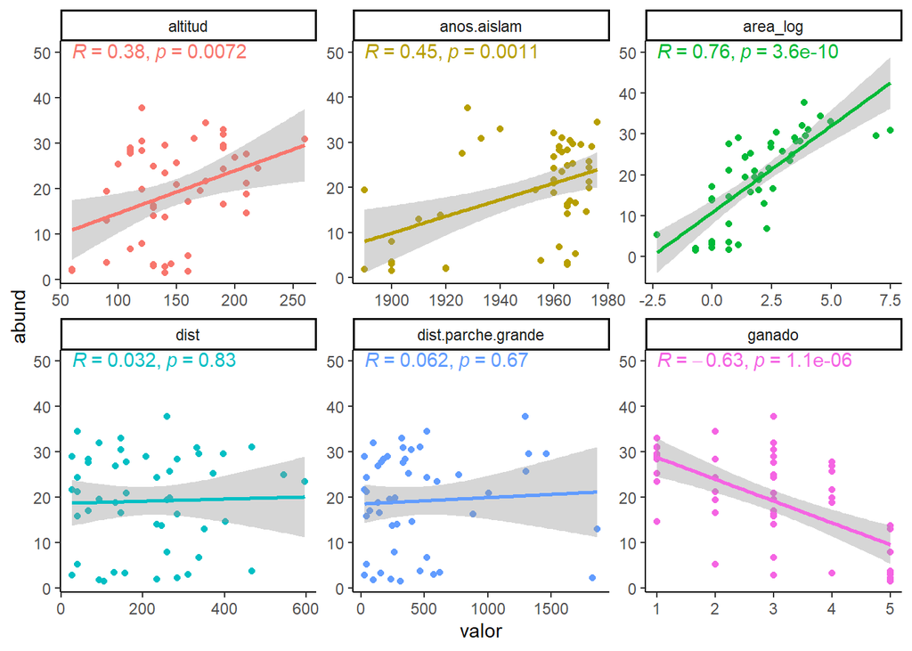

Figura 11: Relación lineal de variables predictoras quitando outliers

```r
# Transformar
aves_transformado_2 <- aves %>%
  mutate(
    area_log = log(area)
    # dist_escalado = (dist) - mean(dist),
    # dist_parche_grande_escal = (dist.parche.grande) - mean(dist.parche.grande)
  )

# eliminar outliers
q_1 <- quantile(aves$dist, probs=c(.25, .75), na.rm = FALSE)
iqr_1 <- IQR(aves$dist)

aves_transformado_2 <- subset(aves_transformado_2, aves_transformado_2$dist > (q_1[1] - 1.5*iqr_1) & aves_transformado_2$dist < (q_1[2]+1.5*iqr_1))

q_2 <- quantile(aves$dist.parche.grande, probs=c(.25, .75), na.rm = FALSE)
iqr_2 <- IQR(aves$dist.parche.grande)

aves_transformado_2 <- subset(aves_transformado_2, aves_transformado_2$dist.parche.grande > (q_2[1] - 1.5*iqr_2) & aves_transformado_2$dist.parche.grande < (q_2[2]+1.5*iqr_2))

# Volver a graficar
aves.gathered.transform <- aves_transformado_2 %>%
  select(
         -area) |>
  gather(key = "variable", value = "valor",
         -abund)

ggplot(aves.gathered.transform,
       aes(x = valor, y = abund, color = variable)) +
  geom_point() +
  geom_smooth(method = "lm") +
  facet_wrap(~ variable, scales = "free") +
  theme_classic() +
  theme(legend.position = "none") +
  stat_cor(method = "pearson", label.y = 50)
```

**Ver código para el dataframe final**

```r
# ahora, el dataframe final será:

aves_final <- aves %>%
  mutate(
    area_log = log(area),
    ganado_factor = as.factor(aves$ganado) # ganado lo pasamos a factor
  )
# eliminar outliers
q_1 <- quantile(aves$dist, probs=c(.25, .75), na.rm = FALSE)
iqr_1 <- IQR(aves$dist)

aves_final <- subset(aves_final, aves_final$dist > (q_1[1] - 1.5*iqr_1) & aves_final$dist < (q_1[2]+1.5*iqr_1))


# str(aves_final)
```

### 5.2 lm con todos los predictores

Ya con los datos transformados, hacemos el modelo lineal para predecir abundancia a partir de las 6 variables:

**Ver código**

```r
lm_aves_todos <- lm(abund ~ altitud + anos.aislam + area_log + dist + dist.parche.grande + ganado_factor, data = aves_final) # ver como usar todas


# summary(lm_aves_todos)

sjPlot::tab_model(lm_aves_todos,
                  show.reflvl = T, # nivel de referencia para factores
                  # show.intercept = F,
                  p.style = "numeric_stars",
                  title = "abund ~ altitud + anos.aislam + area_log + dist + dist.parche.grande + ganado_factor"
                  )
# report::report(lm_aves_todos)
```

Tabla 7: Modelo lineal con 6 predictores

abund ~ altitud + anos.aislam + area_log + dist + dist.parche.grande + ganado_factor

|  | abund |  |  |
| --- | --- | --- | --- |
| Predictors | Estimates | CI | p |
| (Intercept) | 52.71 | -175.10 – 280.51 | 0.643 |
| altitud | -0.00 | -0.05 – 0.05 | 0.905 |
| anos.aislam | -0.02 | -0.13 – 0.10 | 0.747 |
| area_log | 3.26 *** | 1.99 – 4.53 | **<0.001** |
| dist | -0.00 | -0.02 – 0.01 | 0.608 |
| dist.parche.grande | -0.00 | -0.00 – 0.00 | 0.829 |
| ganado_factor2 | 0.85 | -5.64 – 7.35 | 0.793 |
| ganado_factor3 | 0.00 | -5.84 – 5.84 | 0.999 |
| ganado_factor4 | -1.20 | -7.69 – 5.29 | 0.712 |
| ganado_factor5 | -11.97 * | -21.18 – -2.75 | **0.012** |
| Observations | 55 |  |  |
| R<sup>2</sup> / R<sup>2</sup> adjusted | 0.736 / 0.683 |  |  |
| * p<0.05 ** p<0.01 *** p<0.001 |  |  |  |

También podemos ver todas las comparaciones (contrastes) de nuestros factores:

**Ver código**

```r
# Si queremos todas las comparaciones, podemos pedir lo siguiente:

library(gtsummary)

tbl_regression(
  lm_aves_todos,
  add_pairwise_contrasts = T,
  pvalue_fun = ~style_pvalue(.x, digits = 3)
) %>%
  bold_p()
```

Tabla 8: Contrastes del Modelo lineal con 6 predictores

| **Characteristic** | **Beta** | **95% CI**<sup>1</sup> | **p-value** |
| --- | --- | --- | --- |
| altitud | 0.00 | -0.05, 0.05 | 0.905 |
| anos.aislam | -0.02 | -0.13, 0.10 | 0.747 |
| area_log | 3.3 | 2.0, 4.5 | <0.001 |
| dist | 0.00 | -0.02, 0.01 | 0.608 |
| dist.parche.grande | 0.00 | 0.00, 0.00 | 0.829 |
| ganado_factor |  |  |  |
| ganado_factor2 - ganado_factor1 | 0.85 | -8.3, 10 | 0.999 |
| ganado_factor3 - ganado_factor1 | 0.00 | -8.2, 8.2 | >0.999 |
| ganado_factor3 - ganado_factor2 | -0.85 | -8.8, 7.1 | 0.998 |
| ganado_factor4 - ganado_factor1 | -1.2 | -10, 8.0 | 0.996 |
| ganado_factor4 - ganado_factor2 | -2.1 | -11, 6.8 | 0.964 |
| ganado_factor4 - ganado_factor3 | -1.2 | -9.2, 6.8 | 0.993 |
| ganado_factor5 - ganado_factor1 | -12 | -25, 1.0 | 0.085 |
| ganado_factor5 - ganado_factor2 | -13 | -26, 0.57 | 0.066 |
| ganado_factor5 - ganado_factor3 | -12 | -23, -1.4 | 0.020 |
| ganado_factor5 - ganado_factor4 | -11 | -24, 2.4 | 0.156 |

<sup>1</sup> CI = Confidence Interval

Fórmula de regresión:

**Ver código**

```r
equatiomatic::extract_eq(lm_aves_todos)
```

$$\operatorname{abund} = \alpha + \beta_{1}(\operatorname{altitud}) + \beta_{2}(\operatorname{anos.aislam}) + \beta_{3}(\operatorname{area\_\log}) + \beta_{4}(\operatorname{dist}) + \beta_{5}(\operatorname{dist.parche.grande}) + \beta_{6}(\operatorname{ganado\_factor}_{\operatorname{2}}) + \beta_{7}(\operatorname{ganado\_factor}_{\operatorname{3}}) + \beta_{8}(\operatorname{ganado\_factor}_{\operatorname{4}}) + \beta_{9}(\operatorname{ganado\_factor}_{\operatorname{5}}) + \epsilon$$

Los parámetros estandarizados se obtuvieron ajustando el modelo en una versión estandarizada del conjunto de datos. Los intervalos de confianza del 95% (IC) y los valores p se calcularon utilizando una aproximación de la distribución t de Wald.

**Grafico de los estimados del modelo con IC**

**Ver código**

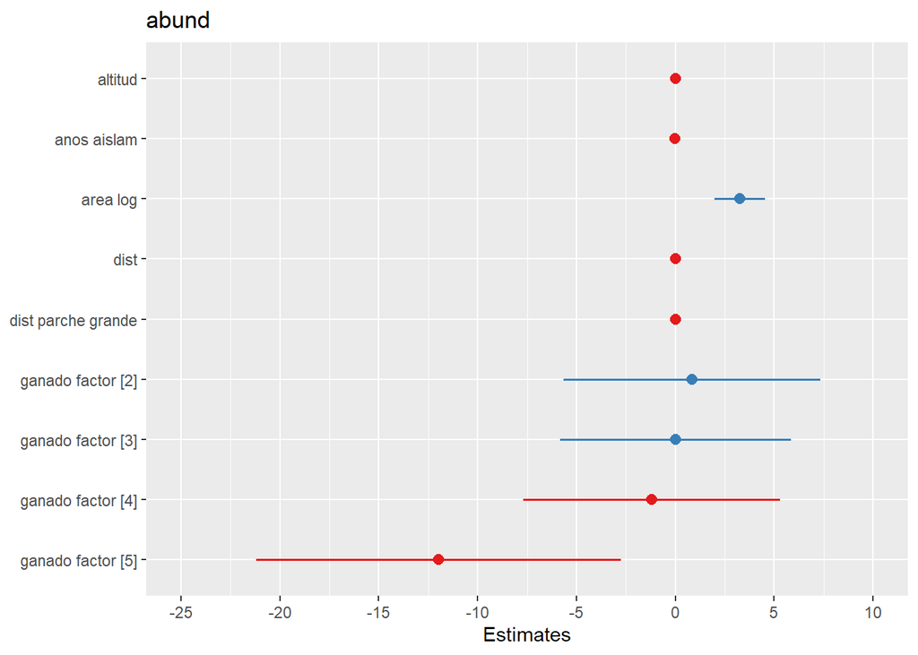

Figura 12

```r
sjPlot::plot_model(lm_aves_todos, type = "est")
```

- Podemos observar cómo el logarítmo del área del parche medido tiene un efecto positivo y significativo sobre la abundancia.
- También se observa cómo el nivel 5 del factor de ganado tiene un efecto negativo y significativo sobre la abundancia.

Adicionalmente, podemos graficar los efectos de cada predictor sobre la variable de respuesta:

**Ver código**

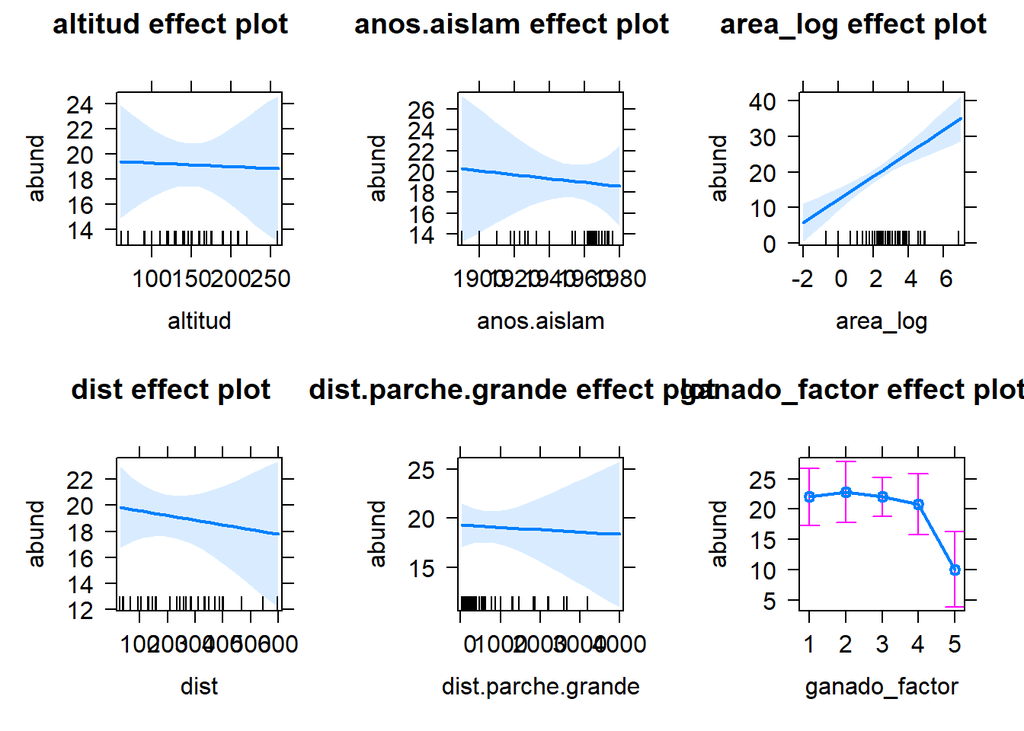

Figura 13

```r
library(effects)
plot(allEffects(lm_aves_todos, grid = TRUE))
```

- Igual se observa cómo area_log y el nivel 5 de ganado tienen una mayor influencia sobre la abundancia.

**Valores predichos para los efectos de cada variable**

Los valores predichos para los efectos de Figura 13 son los siguientes:

```r
library(ggeffects)
ggeffect(lm_aves_todos)
```

```
$altitud
# Predicted values of abund

altitud | Predicted |         95% CI
------------------------------------
     60 |     19.40 | [14.91, 23.89]
     90 |     19.31 | [16.15, 22.47]
    120 |     19.22 | [17.19, 21.26]
    140 |     19.17 | [17.54, 20.79]
    150 |     19.14 | [17.52, 20.75]
    165 |     19.09 | [17.23, 20.95]
    175 |     19.06 | [16.91, 21.22]
    260 |     18.82 | [12.99, 24.64]

$anos.aislam
# Predicted values of abund

anos.aislam | Predicted |         95% CI
----------------------------------------
       1890 |     20.25 | [13.23, 27.28]
       1900 |     20.07 | [14.16, 25.97]
       1910 |     19.88 | [15.07, 24.69]
       1920 |     19.69 | [15.95, 23.44]
       1940 |     19.32 | [17.39, 21.25]
       1950 |     19.14 | [17.53, 20.74]
       1960 |     18.95 | [16.93, 20.97]
       1980 |     18.58 | [14.70, 22.46]

$area_log
# Predicted values of abund

area_log | Predicted |         95% CI
-------------------------------------
      -3 |      2.49 | [-4.19,  9.18]
      -2 |      5.75 | [ 0.29, 11.21]
       0 |     12.26 | [ 9.14, 15.39]
       1 |     15.52 | [13.38, 17.66]
       2 |     18.78 | [17.17, 20.38]
       4 |     25.29 | [22.41, 28.17]
       5 |     28.55 | [24.55, 32.55]
```

[output cut: 30 more lines]

```
$ganado_factor
# Predicted values of abund

ganado_factor | Predicted |         95% CI
------------------------------------------
1             |     22.01 | [17.31, 26.70]
2             |     22.86 | [17.81, 27.90]
3             |     22.01 | [18.74, 25.27]
4             |     20.81 | [15.77, 25.84]
5             |     10.04 | [ 3.77, 16.30]

attr(,"class")
[1] "ggalleffects" "list"
attr(,"model.name")
[1] "lm_aves_todos"
```

Ahora, vamos a ver el desempeño de nuestro modelo:

**Ver código**

```r
performance::performance(lm_aves_todos)
```

```
# Indices of model performance

AIC     |    AICc |     BIC |    R2 | R2 (adj.) |  RMSE | Sigma
---------------------------------------------------------------
362.193 | 368.332 | 384.273 | 0.736 |     0.683 | 5.332 | 5.895
```

**Ver código**

```r
# r2 = cuanta varianza explica nuestro modelo
# ajustada mejor para multivariados porque ajusta a multiples predictores
```

**Ver código**

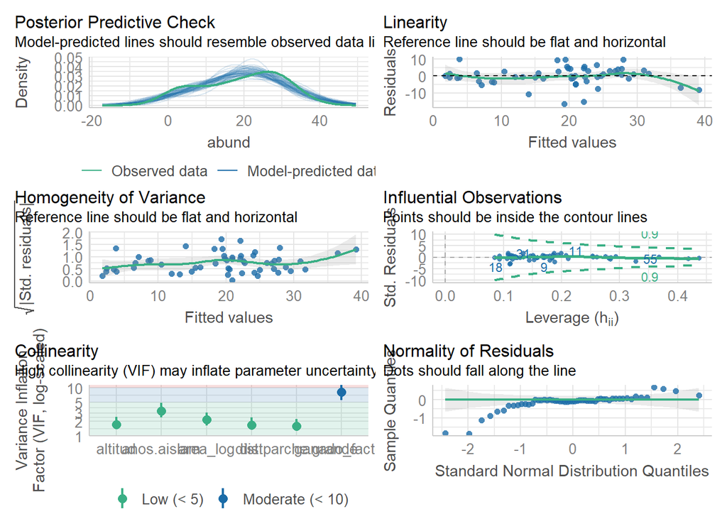

Figura 14: Supuestos del modelo con 6 predictores

```r
performance::check_model(lm_aves_todos)
```

- Parece que nuestro modelo cumple con los supuestos de manera razonable.

### 5.3 Backward

> Utiliza un procedimiento de eliminación backward comenzando con el modelo saturado (con las seis variables) para proponer un modelo múltiple que prediga la abundancia a partir de un subconjunto de las seis variables predictoras.
1. Modelo Saturado:

**Ver código**

```r
modelo_saturado <- lm(abund ~ altitud + anos.aislam + area_log + dist + dist.parche.grande + ganado_factor, data = aves_final)

# summary(modelo_saturado)

tbl_regression(
  modelo_saturado,
  add_pairwise_contrasts = T,
  pvalue_fun = ~style_pvalue(.x, digits = 3)
) %>%
  bold_p()
```

Tabla 9: Modelo backward saturado

| **Characteristic** | **Beta** | **95% CI**<sup>1</sup> | **p-value** |
| --- | --- | --- | --- |
| altitud | 0.00 | -0.05, 0.05 | 0.905 |
| anos.aislam | -0.02 | -0.13, 0.10 | 0.747 |
| area_log | 3.3 | 2.0, 4.5 | <0.001 |
| dist | 0.00 | -0.02, 0.01 | 0.608 |
| dist.parche.grande | 0.00 | 0.00, 0.00 | 0.829 |
| ganado_factor |  |  |  |
| ganado_factor2 - ganado_factor1 | 0.85 | -8.3, 10 | 0.999 |
| ganado_factor3 - ganado_factor1 | 0.00 | -8.2, 8.2 | >0.999 |
| ganado_factor3 - ganado_factor2 | -0.85 | -8.8, 7.1 | 0.998 |
| ganado_factor4 - ganado_factor1 | -1.2 | -10, 8.0 | 0.996 |
| ganado_factor4 - ganado_factor2 | -2.1 | -11, 6.8 | 0.964 |
| ganado_factor4 - ganado_factor3 | -1.2 | -9.2, 6.8 | 0.993 |
| ganado_factor5 - ganado_factor1 | -12 | -25, 1.0 | 0.085 |
| ganado_factor5 - ganado_factor2 | -13 | -26, 0.57 | 0.066 |
| ganado_factor5 - ganado_factor3 | -12 | -23, -1.4 | 0.020 |
| ganado_factor5 - ganado_factor4 | -11 | -24, 2.4 | 0.156 |

<sup>1</sup> CI = Confidence Interval

2. Hacemos la eliminación *Backward* utilizando el criterio AIC utilizando la función `step()`

**Ver código para la función step**

```r
modelo_backward <- step(modelo_saturado, direction = "backward",
                        criteria = "AIC"
                        )
```

3. La ecuación con el mejor criterio AIC por el método *Backward* es la siguiente (`abund ~ area_log + ganado_facto`r):

**Ver código**

```r
equatiomatic::extract_eq(modelo_backward)
```

$$\operatorname{abund} = \alpha + \beta_{1}(\operatorname{area\_\log}) + \beta_{2}(\operatorname{ganado\_factor}_{\operatorname{2}}) + \beta_{3}(\operatorname{ganado\_factor}_{\operatorname{3}}) + \beta_{4}(\operatorname{ganado\_factor}_{\operatorname{4}}) + \beta_{5}(\operatorname{ganado\_factor}_{\operatorname{5}}) + \epsilon$$

4. La tabla de regresión de nuestro modelo óptimo seleccionado por el método *Backward* es el siguiente:

**Ver código**

```r
tbl_regression(
  modelo_backward,
  add_pairwise_contrasts = T,
  pvalue_fun = ~style_pvalue(.x, digits = 3)
) %>%
  bold_p()
```

Tabla 10: Modelo backward óptimo

| **Characteristic** | **Beta** | **95% CI**<sup>1</sup> | **p-value** |
| --- | --- | --- | --- |
| area_log | 3.2 | 2.1, 4.2 | <0.001 |
| ganado_factor |  |  |  |
| ganado_factor2 - ganado_factor1 | 1.4 | -6.7, 9.5 | 0.988 |
| ganado_factor3 - ganado_factor1 | 0.83 | -6.3, 7.9 | 0.997 |
| ganado_factor3 - ganado_factor2 | -0.57 | -7.6, 6.5 | >0.999 |
| ganado_factor4 - ganado_factor1 | -0.58 | -8.8, 7.7 | >0.999 |
| ganado_factor4 - ganado_factor2 | -2.0 | -10, 6.4 | 0.962 |
| ganado_factor4 - ganado_factor3 | -1.4 | -8.8, 6.0 | 0.983 |
| ganado_factor5 - ganado_factor1 | -11 | -19, -2.7 | 0.004 |
| ganado_factor5 - ganado_factor2 | -12 | -20, -4.8 | <0.001 |
| ganado_factor5 - ganado_factor3 | -12 | -18, -5.4 | <0.001 |
| ganado_factor5 - ganado_factor4 | -10 | -18, -2.5 | 0.004 |

<sup>1</sup> CI = Confidence Interval

5. Evaluar el modelo *Backward*:

**Ver código**

```r
performance::performance(modelo_backward)
```

```
# Indices of model performance

AIC     |    AICc |     BIC |    R2 | R2 (adj.) |  RMSE | Sigma
---------------------------------------------------------------
354.893 | 357.276 | 368.945 | 0.733 |     0.706 | 5.366 | 5.685
```

5. Validar supuestos del Modelo *Backward*

**Ver código**

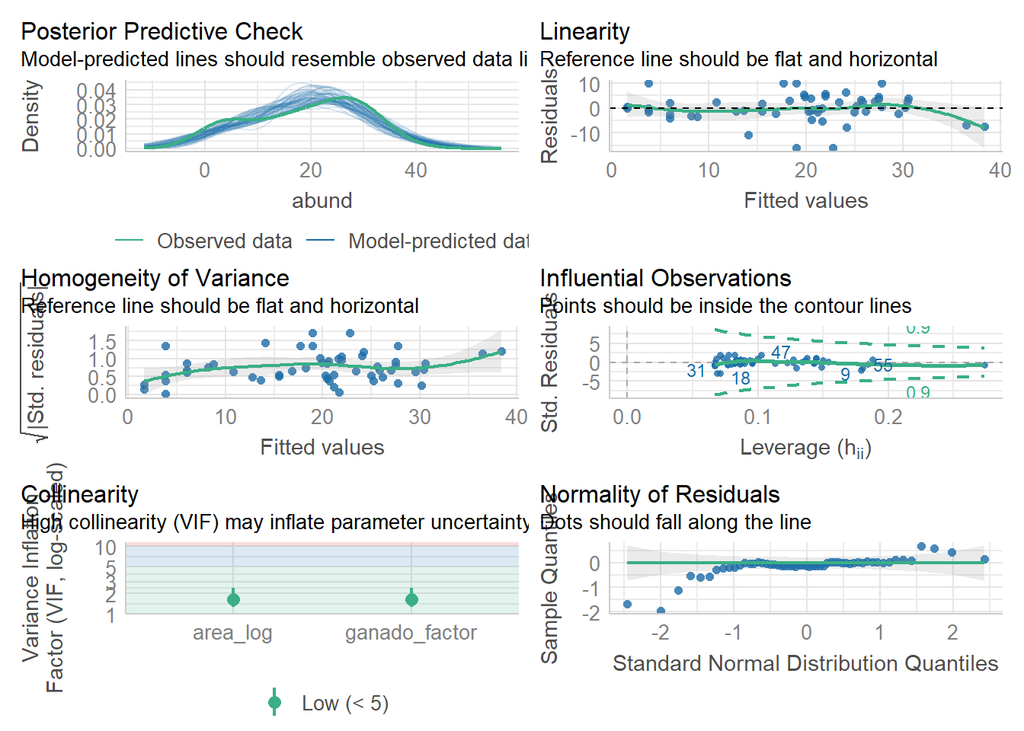

Figura 15: Supuestos del modelo backward óptimo

```r
performance::check_model(modelo_backward)
```

### 5.4 Forward

> Utiliza un procedimiento de selección forward comenzando con un modelo que solamente contenga al intercepto para proponer un modelo múltiple que prediga la abundancia a partir de un subconjunto de las seis variables predictoras.
1. Modelo Nulo (solo intercepto `"abund ~ 1"`)

**Ver código**

```r
modelo_nulo <- lm(abund ~ 1, data = aves_final) # solo intercepto

# summary(modelo_nulo)
```

2. Selección *Forward*

**Ver código para la función step**

```r
# Usando la selección forward con AIC como criterio
modelo_forward <- step(modelo_nulo,
                        scope = list(lower = modelo_nulo, # lower = modelo más simple
                                     upper = modelo_saturado),# upper el modelo más complejo
                        direction = "forward")

# summary(modelo_forward)
```

3. La ecuación con el mejor criterio AIC por el método *Backward* es la siguiente (`abund ~ area_log + ganado_facto`r). Ambos modelos (*Forward* y *Backward*) dieron el mismo resultado.

**Ver código**

```r
equatiomatic::extract_eq(modelo_forward)
```

$$\operatorname{abund} = \alpha + \beta_{1}(\operatorname{area\_\log}) + \beta_{2}(\operatorname{ganado\_factor}_{\operatorname{2}}) + \beta_{3}(\operatorname{ganado\_factor}_{\operatorname{3}}) + \beta_{4}(\operatorname{ganado\_factor}_{\operatorname{4}}) + \beta_{5}(\operatorname{ganado\_factor}_{\operatorname{5}}) + \epsilon$$

4. La tabla de regresión de nuestro modelo óptimo seleccionado por el método *Forward* es el siguiente:

**Ver código**

```r
tbl_regression(
  modelo_forward,
  add_pairwise_contrasts = T,
  pvalue_fun = ~ style_pvalue(.x, digits = 3)
) %>%   bold_p()
```

Tabla 11: Modelo forward óptimo

| **Characteristic** | **Beta** | **95% CI**<sup>1</sup> | **p-value** |
| --- | --- | --- | --- |
| area_log | 3.2 | 2.1, 4.2 | <0.001 |
| ganado_factor |  |  |  |
| ganado_factor2 - ganado_factor1 | 1.4 | -6.7, 9.5 | 0.988 |
| ganado_factor3 - ganado_factor1 | 0.83 | -6.3, 7.9 | 0.997 |
| ganado_factor3 - ganado_factor2 | -0.57 | -7.6, 6.5 | >0.999 |
| ganado_factor4 - ganado_factor1 | -0.58 | -8.8, 7.7 | >0.999 |
| ganado_factor4 - ganado_factor2 | -2.0 | -10, 6.4 | 0.962 |
| ganado_factor4 - ganado_factor3 | -1.4 | -8.8, 6.0 | 0.983 |
| ganado_factor5 - ganado_factor1 | -11 | -19, -2.7 | 0.004 |
| ganado_factor5 - ganado_factor2 | -12 | -20, -4.8 | <0.001 |
| ganado_factor5 - ganado_factor3 | -12 | -18, -5.4 | <0.001 |
| ganado_factor5 - ganado_factor4 | -10 | -18, -2.5 | 0.004 |

<sup>1</sup> CI = Confidence Interval

5. Evaluar el modelo *Forward*:

**Ver código**

```r
performance::performance(modelo_forward)
```

```
# Indices of model performance

AIC     |    AICc |     BIC |    R2 | R2 (adj.) |  RMSE | Sigma
---------------------------------------------------------------
354.893 | 357.276 | 368.945 | 0.733 |     0.706 | 5.366 | 5.685
```

5. Validar supuestos del modelo *Forward*:

**Ver código**

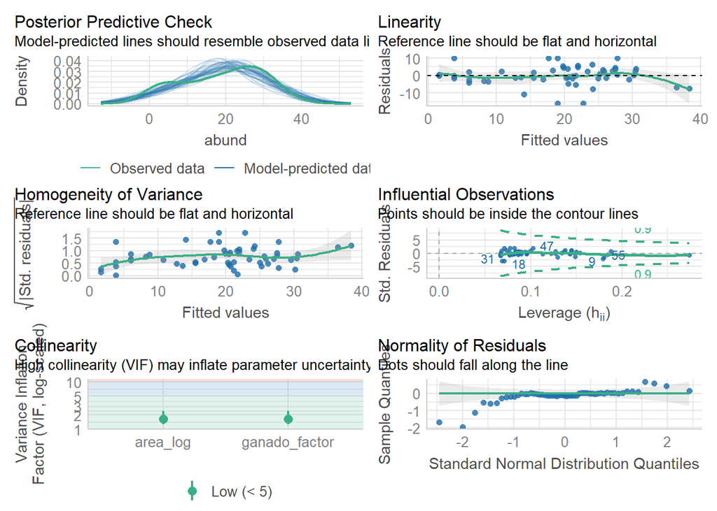

Figura 16: Supuestos del modelo forward óptimo

```r
performance::check_model(modelo_forward)
```

### 5.5 Modelado II

> Utiliza el procedimiento de selección de modelos basado en el AIC para seleccionar un grupo de modelos que predigan la abundancia a partir de un subconjunto de las variables predictoras. Puedes acudir a Burnham et al. 2011 y a Symonds & Moussalli 2011 y al ejercicio que realizamos en clase para revisar de nuevo esta aproximación. Para hacer el ejercicio más sencillo (es decir, para reducir el número de modelos a explorar), utiliza solamente el siguiente conjunto de cuatro variables predictoras en lugar de las seis de los modelos de los incisos previos: *área, ganado, distancia al parche más grande y altitud*. *Explora todos los modelos posibles* para estas cuatro variables y realiza las comparaciones que sean necesarias a través del valor de AIC de los modelos. ¿Cuál sería el conjunto que propondrías como buenos modelos? ¿Cuál es la importancia relativa de las diferentes variables tomando en cuenta su aparición en los diferentes modelos candidatos?

Para explorar TODOS los modelos (incluidas las interacciones), podemos usar el siguiente código a partir del paquete [glmulti](https://www.jstatsoft.org/article/view/v034i12) (Calcagno y Mazancourt 2010).

**Ver código con glmulti**

```r
library(tictoc)  # para tomar el tiempo
library(glmulti) # hace todas las combinaciones posibles con todos los predictores y combinaciones

tictoc::tic()

lm_interaccion <- glmulti(abund ~ altitud + area_log + dist.parche.grande + ganado_factor,
        data = aves_final,
        crit = aic,
        level = 2, # 1 sin interacciones, 2 con interacciones
        method = "g", # se puede usar g para más rápido o h para más exhaustivo
        family = gaussian,
        fitfunction = lm,
        plotty = FALSE,
        confsetsize = 100 # quedarse con mejores 100 modelos
        )

tictoc::toc()
```

Podemos revisar cuántos modelos óptimos obtuvimos (abajo de la línea roja representa los mejores modelos de acuerdo al criterio de *Akaike information criterion*):

**Ver código**

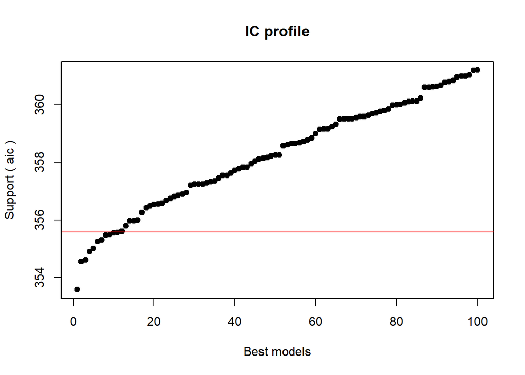

Figura 17: Módelos óptimos basados en AIC

```r
# summary(lm_interaccion)
# coef(lm_interaccion)
plot(lm_interaccion) # abajo de linea roja representa los mejores modelos
```

Los mejores modelos (por criterio de AIC) propuestos son:

**Ver código**

```r
weightable(lm_interaccion)[1:6,] |>
  flextable::flextable()
```

Tabla 12: Módelos óptimos basados en AIC

(\#tab:tbl-aicicoptimos)

| model | aic | weights |
| --- | --- | --- |
| abund ~ 1 + ganado_factor + area_log + ganado_factor:area_log | 353.5732 | 0.06658428 |
| abund ~ 1 + altitud + area_log + dist.parche.grande + area_log:altitud + ganado_factor:altitud | 354.5491 | 0.04087625 |
| abund ~ 1 + altitud + area_log + area_log:altitud + dist.parche.grande:area_log + ganado_factor:altitud | 354.6147 | 0.03955606 |
| abund ~ 1 + ganado_factor + area_log | 354.8935 | 0.03440993 |
| abund ~ 1 + altitud + area_log + area_log:altitud + ganado_factor:altitud | 354.9971 | 0.03267210 |
| abund ~ 1 + ganado_factor + altitud + area_log + ganado_factor:area_log | 355.2517 | 0.02876668 |

Como vemos, el modelo óptimo propuesto es (“abund ~ 1 + ganado_factor + area_log + ganado_factor:area_log)

**Ver código**

```r
# extraer el mejor modelo
lm_interaccion_optimo <- lm_interaccion@objects[[1]]

# print(lm_interaccion)
# summary(lm_interaccion_optimo)

equatiomatic::extract_eq(lm_interaccion_optimo)
```

$$\operatorname{abund} = \alpha + \beta_{1}(\operatorname{ganado\_factor}_{\operatorname{2}}) + \beta_{2}(\operatorname{ganado\_factor}_{\operatorname{3}}) + \beta_{3}(\operatorname{ganado\_factor}_{\operatorname{4}}) + \beta_{4}(\operatorname{ganado\_factor}_{\operatorname{5}}) + \beta_{5}(\operatorname{area\_\log}) + \beta_{6}(\operatorname{ganado\_factor}_{\operatorname{2}} \times \operatorname{area\_\log}) + \beta_{7}(\operatorname{ganado\_factor}_{\operatorname{3}} \times \operatorname{area\_\log}) + \beta_{8}(\operatorname{ganado\_factor}_{\operatorname{4}} \times \operatorname{area\_\log}) + \beta_{9}(\operatorname{ganado\_factor}_{\operatorname{5}} \times \operatorname{area\_\log}) + \epsilon$$

La tabla de regresión de este modelo es la siguiente:

**Ver código**

```r
tbl_regression(
  lm_interaccion_optimo,
  add_pairwise_contrasts = T,
  pvalue_fun = ~ style_pvalue(.x, digits = 3)
) %>%   bold_p()
```

Tabla 13: Resumen del Modelo con interacción

| **Characteristic** | **Beta** | **95% CI**<sup>1</sup> | **p-value** |
| --- | --- | --- | --- |
| ganado_factor |  |  |  |
| ganado_factor2 - ganado_factor1 | -1.1 | -9.7, 7.5 | 0.996 |
| ganado_factor3 - ganado_factor1 | -1.6 | -9.4, 6.2 | 0.979 |
| ganado_factor3 - ganado_factor2 | -0.48 | -7.4, 6.4 | >0.999 |
| ganado_factor4 - ganado_factor1 | -2.8 | -12, 6.0 | 0.890 |
| ganado_factor4 - ganado_factor2 | -1.8 | -9.8, 6.3 | 0.971 |
| ganado_factor4 - ganado_factor3 | -1.3 | -8.5, 5.9 | 0.986 |
| ganado_factor5 - ganado_factor1 | -14 | -23, -4.9 | <0.001 |
| ganado_factor5 - ganado_factor2 | -13 | -22, -4.6 | <0.001 |
| ganado_factor5 - ganado_factor3 | -13 | -20, -5.0 | <0.001 |
| ganado_factor5 - ganado_factor4 | -11 | -20, -2.6 | 0.005 |
| area_log | 1.9 | 0.13, 3.6 | 0.036 |
| ganado_factor * area_log |  |  |  |
| 2 * area_log | 1.8 | -0.78, 4.4 | 0.165 |
| 3 * area_log | 2.1 | -0.87, 5.1 | 0.161 |
| 4 * area_log | 6.6 | 1.6, 12 | 0.011 |
| 5 * area_log | 0.80 | -2.3, 3.9 | 0.601 |

<sup>1</sup> CI = Confidence Interval

La importancia relativa de los términos (evidencia para cada variable en todos los modelos evaluados) es la siguiente:

**Ver código**

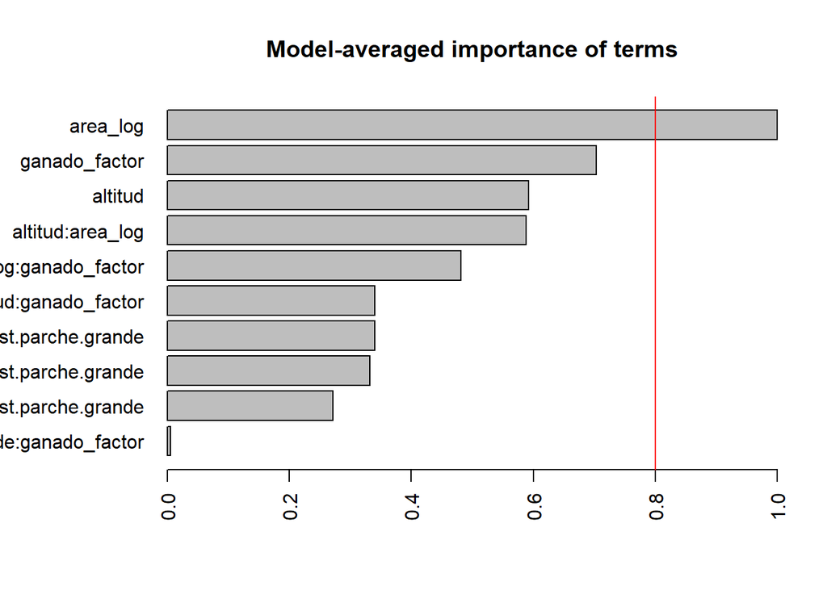

Figura 18: Importancia relativa de los términos

```r
plot(lm_interaccion, type = "s") #threshold is random
```

**Con efectos Mixtos**

También podríamos evaluarlo con efectos mixtos.

- Podríamos considerar altitud como un efecto aletorio; si la influencia de esta variable sobre la abundancia es variada, podría ser un efecto aleatorio.
- Tal vez ganado podría considerarse. Aunque suena más a un efecto fijo, si tenemos varios registros por nivel de ganado o si nos interesa la variabilidad de la respuesta de la abundancia de aves a diferentes niveles de manejo de ganado en varios sitios, podríamos tomarlo como un efecto aleatorio.

```r
# con lme

library(lme4)


# wrapper function
glmer.glmulti <-  function(formula, data, random = "", ...){
  glmer(paste(deparse(formula), random),
        data = data, ...) # REML = F
}

tictoc::tic()

modelo_mixto <- glmulti(
  y = abund ~ area_log + dist.parche.grande + ganado_factor,
  random = "+(1|altitud)",
  crit = aic,
  data = aves_final,
  family = gaussian,
  method = "h",
  plotty = FALSE,
  fitfunc = glmer.glmulti,# wrapper
  marginality = F,
  level = 2
)
```

```
Initialization...
TASK: Exhaustive screening of candidate set.
Fitting...

After 50 models:
Best model: abund~1+ganado_factor+area_log+ganado_factor:area_log
Crit= 330.904738800118
Mean crit= 385.487585313527
Completed.
```

```r
tictoc::toc()
```

```
1 sec elapsed
```

```r
print(modelo_mixto)
```

```
glmulti.analysis
Method: h / Fitting: glmer.glmulti / IC used: aic
Level: 2 / Marginality: FALSE
From 36 models:
Best IC: 330.904738800118
Best model:
[1] "abund ~ 1 + ganado_factor + area_log + ganado_factor:area_log"
Evidence weight: 0.994012070053268
Worst IC: 454.757938515849
1 models within 2 IC units.
0 models to reach 95% of evidence weight.
```

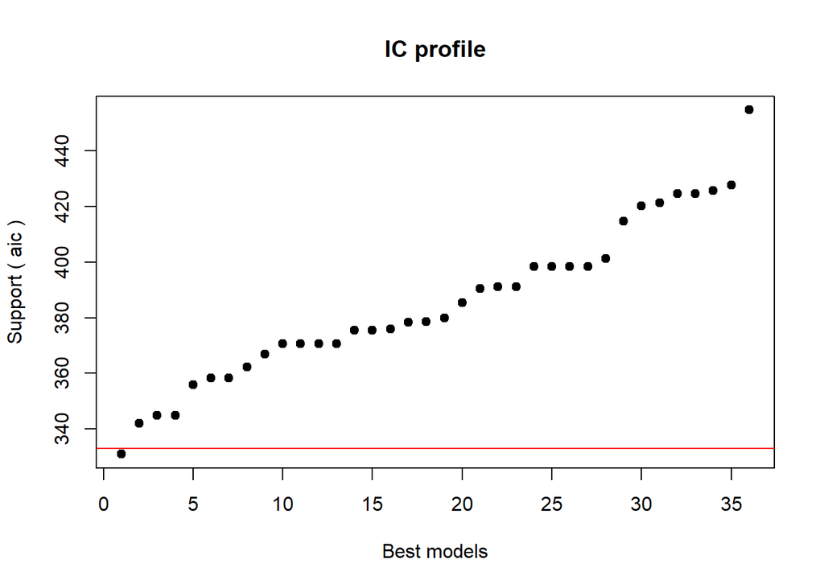

```r
plot(modelo_mixto)
```

```r
lm_multi_optimo_mixto <- modelo_mixto@objects[[1]]
```

Como vemos, parece ser que en este caso llegamos a la misma fórmula y no es necesario considerar los efectos mixtos para mejorar nuestro modelo.

`abund ~ 1 + ganado_factor + area_log + ganado_factor:area_log`

Ahora comparamos nuestro modelo óptimo con los modelos *backward* y *forward*:

**Ver código**

```r
modelo_nulo.2 <- lm(abund ~ 1, data = aves_final)

modelo_saturado.2 <- lm(abund ~ altitud + area_log + dist.parche.grande + ganado_factor, data = aves_final)

backwards_optimo.2 <- step(modelo_saturado.2, direction = "backward",
                           scope = list(upper = modelo_saturado.2,
                                        lower = modelo_nulo.2))

forward_optimo.2 <- step(modelo_nulo.2, direction = "forward",
                         scope = list(upper = modelo_saturado.2,
                                      lower = modelo_nulo.2))
```

Podemos comparar los modelos *backward* y *forward* con la función `anova`:

**Ver código**

```r
# comparar backwards y forward
# Son el mismo
anova(backwards_optimo.2, forward_optimo.2, test = "Chisq")
```

```
Analysis of Variance Table

Model 1: abund ~ area_log + ganado_factor
Model 2: abund ~ area_log + ganado_factor
  Res.Df    RSS Df Sum of Sq Pr(>Chi)
1     49 1583.7
2     49 1583.7  0         0
```

Ambos modelos convergen en la misma fórmula:

```
lm(formula = abund ~ area_log + ganado_factor, data = aves_final)
```

**Ver código**

```r
tbl_regression(
  backwards_optimo.2,
  add_pairwise_contrasts = T,
  pvalue_fun = ~ style_pvalue(.x, digits = 3)
) %>%   bold_p()
```

Tabla 14: Modelo forward y backward óptimo

| **Characteristic** | **Beta** | **95% CI**<sup>1</sup> | **p-value** |
| --- | --- | --- | --- |
| area_log | 3.2 | 2.1, 4.2 | <0.001 |
| ganado_factor |  |  |  |
| ganado_factor2 - ganado_factor1 | 1.4 | -6.7, 9.5 | 0.988 |
| ganado_factor3 - ganado_factor1 | 0.83 | -6.3, 7.9 | 0.997 |
| ganado_factor3 - ganado_factor2 | -0.57 | -7.6, 6.5 | >0.999 |
| ganado_factor4 - ganado_factor1 | -0.58 | -8.8, 7.7 | >0.999 |
| ganado_factor4 - ganado_factor2 | -2.0 | -10, 6.4 | 0.962 |
| ganado_factor4 - ganado_factor3 | -1.4 | -8.8, 6.0 | 0.983 |
| ganado_factor5 - ganado_factor1 | -11 | -19, -2.7 | 0.004 |
| ganado_factor5 - ganado_factor2 | -12 | -20, -4.8 | <0.001 |
| ganado_factor5 - ganado_factor3 | -12 | -18, -5.4 | <0.001 |
| ganado_factor5 - ganado_factor4 | -10 | -18, -2.5 | 0.004 |

<sup>1</sup> CI = Confidence Interval

Ahora, comparamos estos métodos (*forward* y *backward*) con nuestro modelo (“`abund ~ 1 + ganado_factor + area_log + ganado_factor:area_log`”):

**Ver código**

```r
tbl_regression(
  backwards_optimo.2,
  add_pairwise_contrasts = T,
  pvalue_fun = ~ style_pvalue(.x, digits = 3)
) %>%   bold_p()
```

| **Characteristic** | **Beta** | **95% CI**<sup>1</sup> | **p-value** |
| --- | --- | --- | --- |
| area_log | 3.2 | 2.1, 4.2 | <0.001 |
| ganado_factor |  |  |  |
| ganado_factor2 - ganado_factor1 | 1.4 | -6.7, 9.5 | 0.988 |
| ganado_factor3 - ganado_factor1 | 0.83 | -6.3, 7.9 | 0.997 |
| ganado_factor3 - ganado_factor2 | -0.57 | -7.6, 6.5 | >0.999 |
| ganado_factor4 - ganado_factor1 | -0.58 | -8.8, 7.7 | >0.999 |
| ganado_factor4 - ganado_factor2 | -2.0 | -10, 6.4 | 0.962 |
| ganado_factor4 - ganado_factor3 | -1.4 | -8.8, 6.0 | 0.983 |
| ganado_factor5 - ganado_factor1 | -11 | -19, -2.7 | 0.004 |
| ganado_factor5 - ganado_factor2 | -12 | -20, -4.8 | <0.001 |
| ganado_factor5 - ganado_factor3 | -12 | -18, -5.4 | <0.001 |
| ganado_factor5 - ganado_factor4 | -10 | -18, -2.5 | 0.004 |

<sup>1</sup> CI = Confidence Interval

**Ver código**

```r
performance::compare_performance(forward_optimo.2, lm_interaccion_optimo) %>%
  as_tibble() |>
  dplyr::select(- Model, - AIC_wt, -AICc_wt, -BIC_wt, -Sigma) |>
  flextable::flextable()
```

| Name | AIC | AICc | BIC | R2 | R2_adjusted | RMSE |
| --- | --- | --- | --- | --- | --- | --- |
| forward_optimo.2 | 354.8935 | 357.2765 | 368.9448 | 0.7328060 | 0.7055414 | 5.366056 |
| lm_interaccion_optimo | 353.5732 | 359.7128 | 375.6539 | 0.7744559 | 0.7293471 | 4.930122 |

**Ver código**

```r
# nuestro modelo tiene menor AIC, mayor R2, menor RMSE
# Aunque no parece ser demasiada la diferencia
```

Podemos evaluarlos con base en su rendimiento (0-100%). Para esto, el cálculo se basa en normalizar todos los índices (i.e. escalarlos en un rango de 0 a 1) y tomar el valor medio de todos los índices para cada modelo.

**Ver código**

```r
compare_performance(forward_optimo.2, lm_interaccion_optimo, rank = T) %>%
  as_tibble() |>
  dplyr::select(- Model, - AIC_wt, -BIC_wt, -AICc_wt, -Sigma) |>
  flextable::flextable()
```

| Name | R2 | R2_adjusted | RMSE | Performance_Score |
| --- | --- | --- | --- | --- |
| lm_interaccion_optimo | 0.7744559 | 0.7293471 | 4.930122 | 0.7142857 |
| forward_optimo.2 | 0.7328060 | 0.7055414 | 5.366056 | 0.2857143 |

Podemos graficar este rendimiento en un gráfico `spiderweb` donde los índices son normalizados (mayores valores indican mejor rendimiento).

**Ver código**

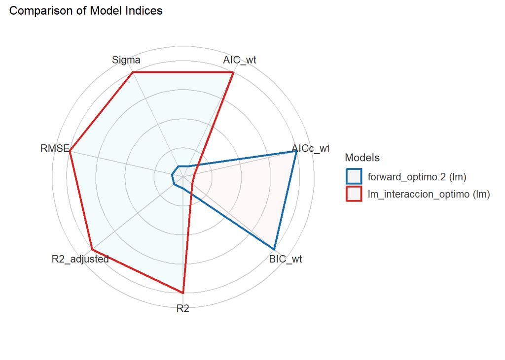

Figura 19: Spiderweb comparando modelos

```r
plot(compare_performance(forward_optimo.2, lm_interaccion_optimo))
```

### 5.6 Comparar modelos

> Compara los resultados obtenidos con los diferentes métodos de selección de modelos. ¿A qué conclusión llegamos que conteste la pregunta principal de investigación?

La principal diferencia entre los dos modelos lineales (obtenido por método forward/backward y nuestro modelado) es la inclusión de un término de interacción en el segundo modelo.

Modelo *forward/backward* **`lm(formula = abund ~ area + ganado)`**

Este modelo es un modelo lineal simple que incluye dos predictores: **`area`** y **`ganado`**. Esta fórmula modela la abundancia de aves como una función lineal del área del parche y la cantidad de ganado presente, sin considerar cómo la combinación de estos dos factores podría afectar de manera conjunta la abundancia de aves. En este modelo, los coeficientes para **`area`** y **`ganado`** representan el cambio esperado en la abundancia de aves por cada unidad de cambio en **`area`** y **`ganado`**, respectivamente, asumiendo que el otro predictor se mantiene constante.

Modelo 2 **`lm(formula = abund ~ 1 + ganado + area + ganado:area)`**

Este modelo también incluye una interacción entre **`ganado`** y **`area`**. El término de interacción **`ganado:area`** examina cómo el efecto de una variable (por ejemplo, **`ganado`**) sobre la abundancia de aves cambia dependiendo del nivel de la otra variable (**`area`**), y viceversa.

- **Efectos principales**: Los coeficientes de **`ganado`** y **`area`** todavía representan el efecto de cada uno de estos predictores sobre la abundancia de aves, pero ahora estos efectos son condicionales al nivel de la otra variable siendo en su nivel base (el nivel más bajo).
- **Término de interacción**: El coeficiente de **`ganado:area`** indica cuánto cambia el efecto de **`ganado`** sobre la abundancia por cada unidad de incremento en **`area`**, y viceversa. Si este coeficiente es significativamente diferente de cero, implica que el efecto de una variable sobre la abundancia de aves depende del nivel de la otra variable.

Podemos ver la diferencia de los estimados en nuestros dos modelos de la siguiente manera (abundancia 2 en rojo corresponde al modelo con interacción, abundancia 1 en azul al modelo sin interacción):

**Ver código**

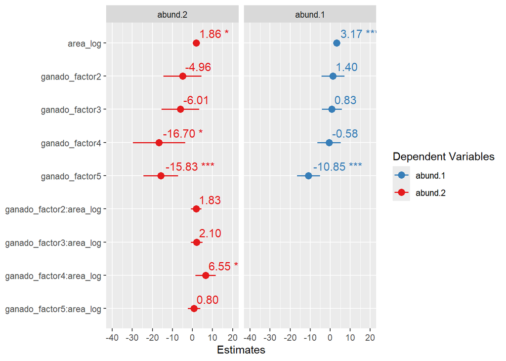

Figura 20: Comparación de estimados de los 2 modelos

```r
# de lado izquierdo (abund.2) tenemos nuestro modelo con interacción
# de lado derecho el modelo obtenido por forward/backward
sjPlot::plot_models(forward_optimo.2, lm_interaccion_optimo, show.values = T, grid = T)
```

**Ver código**

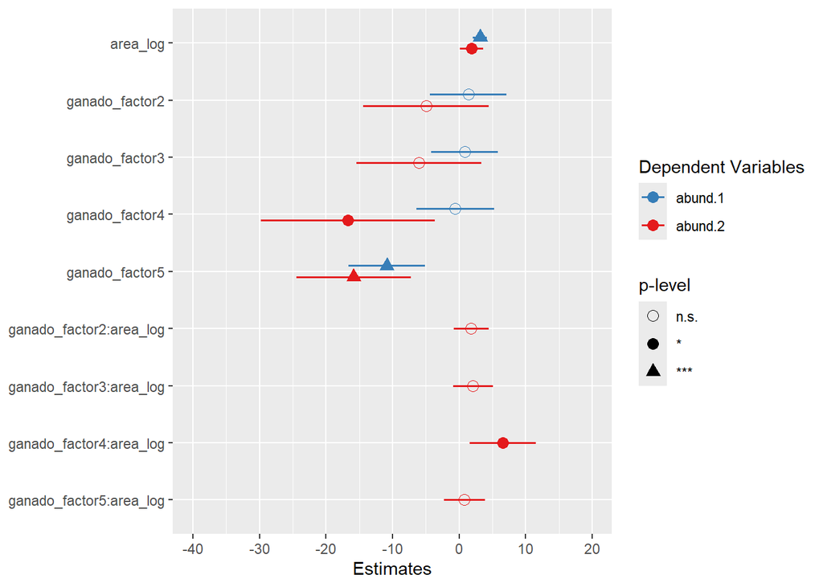

Figura 21: Comparación de estimados de los 2 modelos 2

```r
sjPlot::plot_models(forward_optimo.2, lm_interaccion_optimo, p.shape = T) # collapse.ci = T
```

Por último, podemos visualizar los efectos sobre la variable de respuesta de nuestro modelo de interacción:

**Ver código**

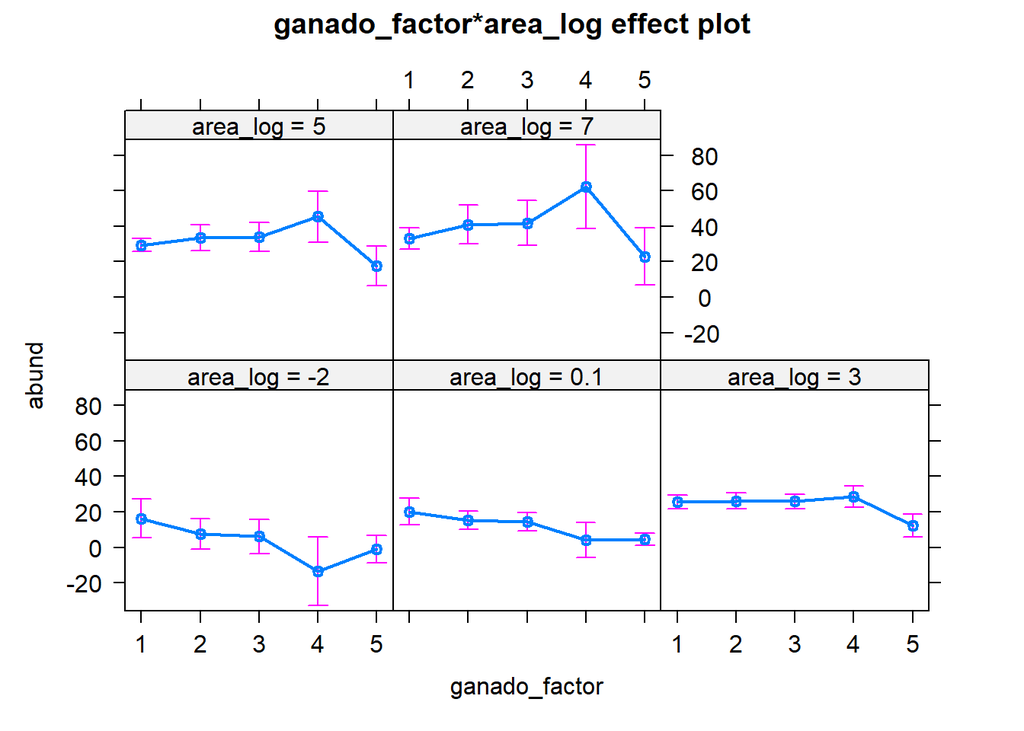

Figura 22: Efectos sobre la variable de respuesta con modelo de interacción

```r
# library(effects)
plot(allEffects(lm_interaccion_optimo, grid = TRUE))
```

**Ver código**

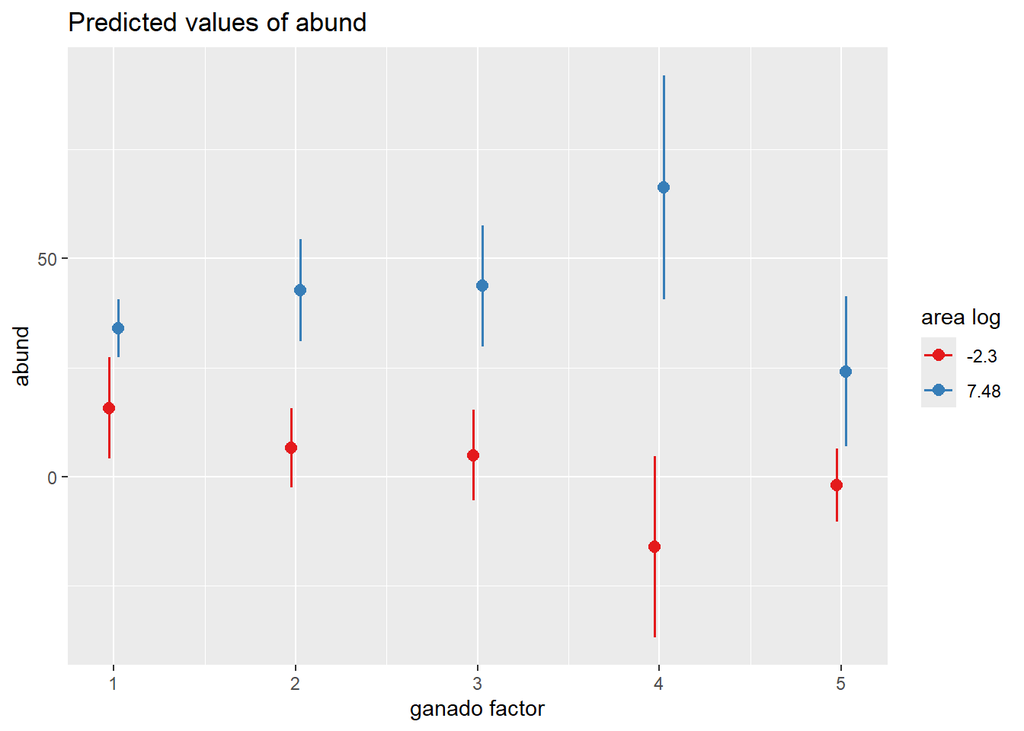

Figura 23: Efectos marginales de los términos de interacción

```r
# library(sjPlot)
plot_model(lm_interaccion_optimo, type = "int")
```

## Referencias

Calcagno, Vincent, y Claire de Mazancourt. 2010. «**Glmulti**: An*R*Package for Easy Automated Model Selection with (Generalized) Linear Models». *Journal of Statistical Software* 34 (12). https://doi.org/10.18637/jss.v034.i12.